# act-report

## WeRateDogs Twitter Users Activity Data Analysis and Visualizations

#### By Diane Uwiduhaye

WeRateDogs is a Twitter account that rates people's dogs with a humorous comment about the dogs. The dogs most always have a denominator of 10 but the numerators almost always have a greater value than 10 which is what makes it unique. WeRateDogs has over 4 million followers on twitter and has received international coverage. Going through the twitter page and the data I have gathered, assessed and cleaned, I was wondering what exactly are the user’s activities on this page.

My focus went to the relationship between the user interactions and the dog stages, firstly, there are seven dog stages; doggo,doggo-floofer,doggo-pupper,doggo-puppo ,floofer,pupper,puppo.But the main ones are four apart from the combined ones; doggo, floofer, pupper, and puppo.

I will briefly explain the different dog stages below.

· Doggo - This stage of dog is explained as a bigger pupper, in short, an adult dog.

· Pupper - A small doggo, it is usually younger.

· Puppo - This stage is the stage between pupper and doggo. It is the equivalent of a teenager.

· Floofer - This is a dog with fur.

What is the relationship between dog_stage and people's interactions either in Likes and Retweets Although a lot of dog stages data could not be retrieved during the wrangling process, I worked with the ones available.

From my analysis, using the histograms below comparing dog stages and the like counts, dog stages and the retweets counts accumulated by each stage against each other.

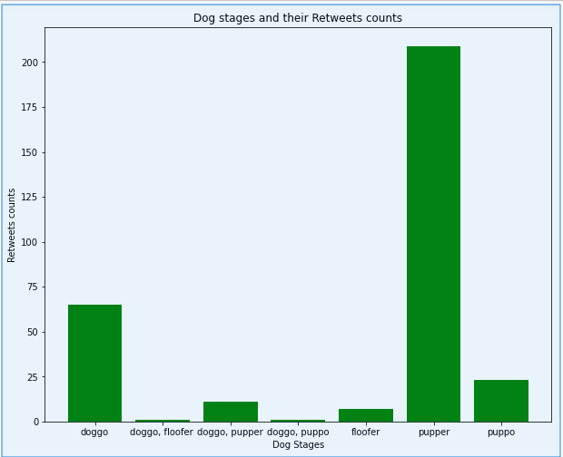

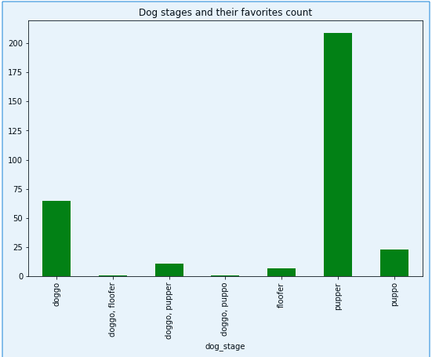

• doggo,floofer and doggo,puppo stages are the least to retweeted and liked.